# Rare, extreme weather events have the greatest human and economic costs

Marcus Carr

August 23, 2014

# Synopsis

Data from NOAA on injuries, fatalities, property damage, and crop damage due to inclement weather were analyzed. We most closely examined data in the years 1993-2011, which appeared to be the most complete.

The most common causes of injury or fatality were tornadoes, flooding, and excessive heat. The types of weather most likely to cause these involved high winds and extreme temperatures. Though more common types of weather, such as thunderstorms and snow, also caused many injuries and deaths, those events are much more frequent. Public health interventions would have the greatest effect if focused on rare, extreme weather events.

For property damage, the most damage is caused by water and high winds associated with floods and tropical weather systems. Crop damages are most often caused by drought and flooding. Measures against these types of damage are more difficult to implement.

# Data processing

## Preliminaries.

### Initial setup.

```r
library(plyr)
library(ggplot2)
library(grid)
library(gridExtra)
library(knitr)
library(stringr)

# The data take a long time to read in. Comment out with caution.
opts_chunk$set(cache=TRUE)

setwd("~/coursera/repdata/RepData_PeerAssessment2")
```

### Download the file.

```r
# Set up variables for downloading the file.
fileURL <- "https://d396qusza40orc.cloudfront.net/repdata%2Fdata%2FStormData.csv.bz2"
filename <- "repdata%2Fdata%2FStormData.csv.bz2"

# Download the file if necessary.
if (!file.exists(filename)) {
        download.file(fileURL, destfile = filename, method = "curl")
        }
```

### Read in the data.

The EVTYPE field has extra whitespaces, which need to be removed.

```r
# Create the file handle.
fh <- bzfile(filename)

# Read in the data.
if (!exists("storm_data_bk")) {
        storm_data <- read.csv(fh, strip.white = TRUE)
        storm_data_bk <- storm_data
        } else storm_data <- storm_data_bk

# Strip remaining whitespace from EVTYPE.
storm_data$EVTYPE <- str_trim(storm_data$EVTYPE)

# Also download some documentation.
doc1URL <- "https://d396qusza40orc.cloudfront.net/repdata%2Fpeer2_doc%2Fpd01016005curr.pdf"
doc1name <- "repdata%2Fpeer2_doc%2Fpd01016005curr.pdf"
if (!file.exists(doc1name)) {
        download.file(doc1URL, destfile = doc1name, method = "curl")
        }

faqURL <- "https://d396qusza40orc.cloudfront.net/repdata%2Fpeer2_doc%2FNCDC%20Storm%20Events-FAQ%20Page.pdf"
faqname <- "repdata%2Fpeer2_doc%2FNCDC%20Storm%20Events-FAQ%20Page.pdf"
if (!file.exists(faqname)) {
        download.file(faqURL, destfile = faqname, method = "curl")
        }
```

## Data cleanup.

We will also clean up the begin and end dates so that we can pick only more recent (that is, better) records. Also the cases in EVTYPE need to be made consistant. There are some clear typos, but they are relatively rare. Most of the data are well-annotated.

```r
storm_data$BGN_DATE <- as.Date(storm_data$BGN_DATE, format = "%m/%d/%Y")
storm_data$BGN_DATE_YEAR <- format(storm_data$BGN_DATE, "%Y")
storm_data$END_DATE <- as.Date(storm_data$END_DATE, format = "%m/%d/%Y")
storm_data$END_DATE_YEAR <- format(storm_data$END_DATE, "%Y")

storm_data$EVTYPE <- as.factor(tolower(storm_data$EVTYPE))
```

We will assume that the fine distinctions made in the `EVTYPE` variable are significant and retain them during our analysis. For example, a “flash flood” and a “river flood” would require different types of preparation.

## Overview of the data.

First, let’s look at the type of information in this data set. We are most interested in variables that can relate event types (`EVTYPE`) to economic or health measures. We also want to see how most of the events are described.

```r
names(storm_data)
```

```
##  [1] "STATE__"       "BGN_DATE"      "BGN_TIME"      "TIME_ZONE"
##  [5] "COUNTY"        "COUNTYNAME"    "STATE"         "EVTYPE"
##  [9] "BGN_RANGE"     "BGN_AZI"       "BGN_LOCATI"    "END_DATE"
## [13] "END_TIME"      "COUNTY_END"    "COUNTYENDN"    "END_RANGE"
## [17] "END_AZI"       "END_LOCATI"    "LENGTH"        "WIDTH"
## [21] "F"             "MAG"           "FATALITIES"    "INJURIES"
## [25] "PROPDMG"       "PROPDMGEXP"    "CROPDMG"       "CROPDMGEXP"
## [29] "WFO"           "STATEOFFIC"    "ZONENAMES"     "LATITUDE"
## [33] "LONGITUDE"     "LATITUDE_E"    "LONGITUDE_"    "REMARKS"
## [37] "REFNUM"        "BGN_DATE_YEAR" "END_DATE_YEAR"
```

```r
sum_EVTYPE <- count(storm_data$EVTYPE)
names(sum_EVTYPE) <- c("event", "freq")
sum_EVTYPE <- sum_EVTYPE[order(-sum_EVTYPE$freq),]
```

The variables `FATALITIES` and `INJURIES` will be used for health outcomes. The variables `PROPDMG` and `CROPDMG` will be used for economic outcomes. There are 890 descriptors among 902297 events. That seems high, but we will focus on *likelihood* of injury or fatality with an event and on *total* economic damage, so it seems reasonable to ignore this for now.

# Data analysis

## Health outcomes

We need to select a cutoff for those numbers to classify weather events as having a significant effect on health. First, we consider the distribution of events.

```r
summary(storm_data$INJURIES)
```

```
##    Min. 1st Qu.  Median    Mean 3rd Qu.    Max.
##     0.0     0.0     0.0     0.2     0.0  1700.0
```

```r
summary(storm_data$FATALITIES)
```

```
##    Min. 1st Qu.  Median    Mean 3rd Qu.    Max.
##       0       0       0       0       0     583
```

Most events report neither injuries nor fatalities, which is interesting. To start, we summarize the data by year.

```r
health_year <- ddply(storm_data, .(BGN_DATE_YEAR), summarize,
                     mean_INJURIES = mean(INJURIES),
                     total_INJURIES = sum(INJURIES),
                     mean_FATALITIES = mean(FATALITIES),
                     total_FATALITIES = sum(FATALITIES))
```

Let’s look at some statistics and time graphs on injuries and fatalities with these events.

```r
quantile(storm_data$INJURIES, probs = c(0, 0.5, 0.9, 0.95, 1))
```

```
##   0%  50%  90%  95% 100%
##    0    0    0    0 1700
```

```r
quantile(storm_data$FATALITIES, probs = c(0, 0.5, 0.9, 0.95, 1))
```

```
##   0%  50%  90%  95% 100%
##    0    0    0    0  583
```

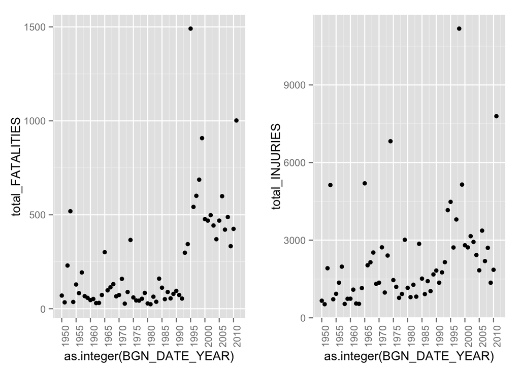

```r
plotyears <- seq(min(as.integer(health_year$BGN_DATE_YEAR)),
                 max(as.integer(health_year$BGN_DATE_YEAR)), by = 5)
q1 <- qplot(x = as.integer(BGN_DATE_YEAR), y = total_FATALITIES,
            data = health_year) +
        scale_x_continuous(breaks = plotyears) +
        theme(axis.text.x = element_text(angle = 90))
q2 <- qplot(x = as.integer(BGN_DATE_YEAR), y = total_INJURIES,
            data = health_year) +
        scale_x_continuous(breaks = plotyears) +
        theme(axis.text.x = element_text(angle = 90))
grid.arrange(q1, q2, ncol = 2)
```

It seems like data collection got a lot better around 1993, so we will look only at events in 1993 or later.

```r
year_cutoff = "1993"
storm_data_subset <- subset(storm_data, BGN_DATE_YEAR >= year_cutoff)
sum_subset_EVTYPE <- count(storm_data_subset$EVTYPE)
sum_subset_EVTYPE <- sum_subset_EVTYPE[order(-sum_subset_EVTYPE$freq),]
nevents <- sum(sum_subset_EVTYPE$freq)
total_injuries <- sum(storm_data_subset$INJURIES)
total_fatalities <- sum(storm_data_subset$FATALITIES)
health_type <- ddply(storm_data_subset, .(EVTYPE), summarize,
                     mean_INJURIES = mean(INJURIES),
                     total_INJURIES = sum(INJURIES),
                     proportion_INJURIES = sum(INJURIES) / total_injuries,
                     mean_FATALITIES = mean(FATALITIES),
                     total_FATALITIES = sum(FATALITIES),
                     proportion_FATALITIES = sum(FATALITIES) /
                             total_fatalities)
```

For planning purposes, both the frequency and likelihood of injuries or fatalities from an event would be of interest.

```r
top_injuries <- as.character(health_type[with(
        health_type, order(-total_INJURIES)), ]$EVTYPE[1:10])
mean_injuries <- as.character(health_type[with(
        health_type, order(-mean_INJURIES)), ]$EVTYPE[1:10])
top_fatalities <- as.character(health_type[with(
        health_type, order(-total_FATALITIES)), ]$EVTYPE[1:10])
mean_fatalities <- as.character(health_type[with(
        health_type, order(-mean_FATALITIES)), ]$EVTYPE[1:10])
```

## Economic outcomes

`PROPDMGEXP` and `CROPDMGEXP` are order-of-magnitude indicators. We will need to combine this information with the PROPDMG and CROPDMG colums, respectively. The actual value of property damage will be in the “property_damage” variable, and the actual value of crop damage will be in the “crop_damage” variable.

The meaning of the other “EXP” column values is unclear and is not documented. A quick inspection of those events shows that they are mostly minor. The economic impact of those events will be ignored.

```r
storm_data_subset$property_damage <- rep(NA, nrow(storm_data_subset))
storm_data_subset$crop_damage <- rep(NA, nrow(storm_data_subset))

storm_data_prop_K <- storm_data_subset$PROPDMGEXP == "K" |
        storm_data_subset$PROPDMGEXP == "k"
storm_data_prop_M <- storm_data_subset$PROPDMGEXP == "M" |
        storm_data_subset$PROPDMGEXP == "m"
storm_data_prop_B <- storm_data_subset$PROPDMGEXP == "B" |
        storm_data_subset$PROPDMGEXP == "b"


storm_data_subset[storm_data_prop_K, ]$property_damage <-
        storm_data_subset[storm_data_prop_K, ]$PROPDMG * 10^3
storm_data_subset[storm_data_prop_M, ]$property_damage <-
        storm_data_subset[storm_data_prop_M, ]$PROPDMG * 10^6
storm_data_subset[storm_data_prop_B, ]$property_damage <-
        storm_data_subset[storm_data_prop_B, ]$PROPDMG * 10^9


storm_data_crop_K <- storm_data_subset$CROPDMGEXP == "K" |
        storm_data_subset$CROPDMGEXP == "k"
storm_data_crop_M <- storm_data_subset$CROPDMGEXP == "M" |
        storm_data_subset$CROPDMGEXP == "m"
storm_data_crop_B <- storm_data_subset$CROPDMGEXP == "B" |
        storm_data_subset$CROPDMGEXP == "b"


storm_data_subset[storm_data_crop_K, ]$crop_damage <-
        storm_data_subset[storm_data_crop_K, ]$CROPDMG * 10^3
storm_data_subset[storm_data_crop_M, ]$crop_damage <-
        storm_data_subset[storm_data_crop_M, ]$CROPDMG * 10^6
storm_data_subset[storm_data_crop_B, ]$crop_damage <-
        storm_data_subset[storm_data_crop_B, ]$CROPDMG * 10^9

econ_storm_data <- subset(storm_data_subset,
                          !is.na(property_damage) | !is.na(crop_damage))
```

Similar to the treatment of the health data, let’s look at the distribution of the economic effects of weather events.

```r
summary(econ_storm_data$property_damage)
```

```
##     Min.  1st Qu.   Median     Mean  3rd Qu.     Max.     NA's
## 0.00e+00 0.00e+00 1.00e+03 9.89e+05 1.00e+04 1.15e+11     4320
```

```r
summary(econ_storm_data$crop_damage)
```

```
##     Min.  1st Qu.   Median     Mean  3rd Qu.     Max.     NA's
## 0.00e+00 0.00e+00 0.00e+00 1.73e+05 0.00e+00 5.00e+09   121741
```

Similar to the health data, we summarize by event type and year.

```r
econ_year <- ddply(econ_storm_data, .(BGN_DATE_YEAR), summarize,
                   mean_property_damage = mean(property_damage, na.rm = TRUE),
                   total_property_damage = sum(property_damage, na.rm = TRUE),
                   mean_crop_damage = mean(crop_damage, na.rm = TRUE),
                   total_crop_damage = sum(crop_damage, na.rm = TRUE))
```

```r
quantile(econ_storm_data$property_damage, probs = c(0, 0.5, 0.9, 0.95, 1),
         na.rm = TRUE)
```

```
##       0%      50%      90%      95%     100%
## 0.00e+00 1.00e+03 5.00e+04 2.00e+05 1.15e+11
```

```r
quantile(econ_storm_data$crop_damage, probs = c(0, 0.5, 0.9, 0.95, 1),
         na.rm = TRUE)
```

```
##    0%   50%   90%   95%  100%
## 0e+00 0e+00 0e+00 7e+03 5e+09
```

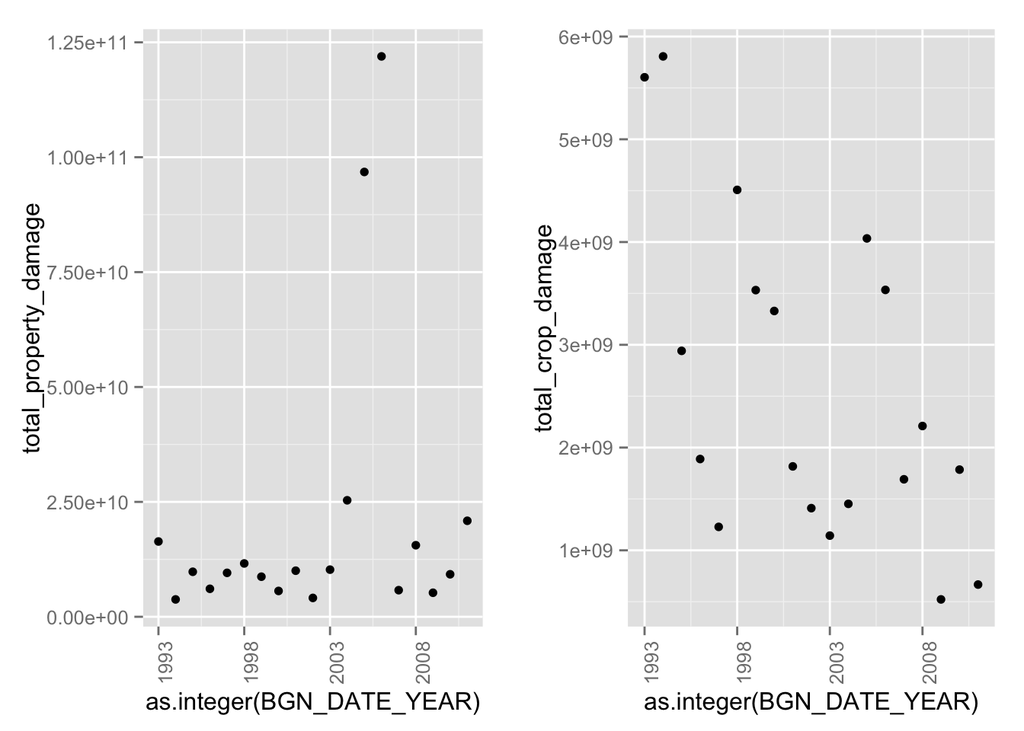

```r
plotyears <- seq(min(as.integer(econ_year$BGN_DATE_YEAR)),
                 max(as.integer(econ_year$BGN_DATE_YEAR)), by = 5)
q1 <- qplot(x = as.integer(BGN_DATE_YEAR), y = total_property_damage,
            data = econ_year) +
        scale_x_continuous(breaks = plotyears) +
        theme(axis.text.x = element_text(angle = 90))
q2 <- qplot(x = as.integer(BGN_DATE_YEAR), y = total_crop_damage,
            data = econ_year) +
        scale_x_continuous(breaks = plotyears) +
        theme(axis.text.x = element_text(angle = 90))
grid.arrange(q1, q2, ncol = 2)
```

The 1993-2011 data look to be complete. We summarize the data during that time by event type.

```r
econ_storm_data <- subset(econ_storm_data, BGN_DATE_YEAR >= year_cutoff)

econ_type <- ddply(econ_storm_data, .(EVTYPE), summarize,
                   total_property_damage = sum(property_damage, na.rm = TRUE),
                   total_crop_damage = sum(crop_damage, na.rm = TRUE))
```

For the economics data, total property and crop damages are the most useful.

```r
top_property <- as.character(econ_type[with(econ_type, order(
        -total_property_damage)),]$EVTYPE[1:10])
top_crop <- as.character(econ_type[with(econ_type, order(
        -total_crop_damage)), ]$EVTYPE[1:10])
```

# Results

```r
kable(cbind(rank = seq(1:10), injuries = top_injuries,
            fatalities = top_fatalities))
```

[output not shown]

The ten types of events most likely to cause injury or fatality in the same time period were:

```r
kable(cbind(rank = seq(1:10), injuries = mean_injuries,
            fatalities = mean_fatalities))
```

[output not shown]

The top causes (by total cost) of property and crop damage in 1993-2011 were:

```r
kable(cbind(rank = seq(1:10), property = top_property,
            crop = top_crop))
```

[output not shown]